# Lecture 212

2021-09-11

## Tidy data

**CONTENT WARNING:**  
Some of the data used in these slides discuss issues that some people might find distressing: **disease**.

## Recap

**Prev**: Join operations

- Joining data
- dplyr join functions

**Now**: Tidy-up your data

- Wide and long data
- Re-shape data
- Handle missing values

## Long data

Each real-world entity is represented by *multiple rows*

- each one reporting only one of its attributes
- one column indicates which attribute each row represent
- another column is used to report the value

Common approach for temporal series

| city | week_ending | cases |
| --- | --- | --- |
| Derby | 2020-10-03 | NA |
| Leicester | 2020-10-03 | 473 |
| Nottingham | 2020-10-03 | 1701 |
| Derby | 2020-10-10 | 320 |
| Leicester | 2020-10-10 | 616 |
| Nottingham | 2020-10-10 | NA |

## Wide data

Each real-world entity is represented by *one single row*

- its attributes are represented through different columns

| city | cases_2020_10_03 | cases_2020_10_10 |
| --- | --- | --- |
| Derby | NA | 320 |
| Leicester | 473 | 616 |
| Nottingham | 1701 | NA |

- **Long data** can be more flexible
  - new attributes add new rows where necessary
- **Wide data** require more structure
  - new attributes need new column for all entities

## Example

```r
city_info_long <- data.frame(
    city = c("Derby", "Leicester" , "Nottingham",
             "Derby", "Leicester", "Nottingham"),
    week_ending = c("2020-10-03", "2020-10-03", "2020-10-03",
                    "2020-10-10", "2020-10-10", "2020-10-10"),
    cases = c(NA, 473, 1701, 320, 616, NA)
  ) %>%
  tibble::as_tibble()
```

| city | week_ending | cases |
| --- | --- | --- |
| Derby | 2020-10-03 | NA |
| Leicester | 2020-10-03 | 473 |
| Nottingham | 2020-10-03 | 1701 |
| Derby | 2020-10-10 | 320 |
| Leicester | 2020-10-10 | 616 |
| Nottingham | 2020-10-10 | NA |

## tidyr

The [`tidyr`](https://tidyr.tidyverse.org/) (pronounced *tidy-er*) library is part of [`tidyverse`](https://www.tidyverse.org/)

Provides a series of functions to *“tidy-up”* your data, including

- re-shape your data
  - [`tidyr::pivot_wider`](https://tidyr.tidyverse.org/reference/pivot_wider.html): pivot from long to wide
  - [`tidyr::pivot_longer`](https://tidyr.tidyverse.org/reference/pivot_longer.html): pivot from wide to long
- handle missing values
  - [`tidyr::drop_na`](https://tidyr.tidyverse.org/reference/drop_na.html): remove rows with missing data
  - [`tidyr::replace_na`](https://tidyr.tidyverse.org/reference/replace_na.html): replace missing data
  - [`tidyr::fill`](https://tidyr.tidyverse.org/reference/replace_na.html): fill missing data
  - [`tidyr::complete`](https://tidyr.tidyverse.org/reference/complete.html): add missing value combinations

## tidyr::pivot_wider

Re-shape from **long** to **wide** format

```r
city_info_wide <-
  city_info_long %>%
  tidyr::pivot_wider(
    # Column from which to extract new column names
    names_from = week_ending,
    # Column from which to extract values
    values_from = cases
  )
```

| city | 2020-10-03 | 2020-10-10 |
| --- | --- | --- |
| Derby | NA | 320 |
| Leicester | 473 | 616 |
| Nottingham | 1701 | NA |

## tidyr::pivot_wider

It might be useful (or indeed necessary) to **format** the values that will become the names of the new columns

```r
city_info_wide <- city_info_long %>% dplyr::mutate(
    # Change "-" to "_" in the string representing the dates
    week_ending = stringr::str_replace_all(week_ending, "-", "_")
  ) %>%
  tidyr::pivot_wider(
    names_from = week_ending, values_from = cases, # As before
    names_prefix = "cases_" # Add a prefix
  ) # Apologies for bad coding style, need to fit code in slide :)
```

| city | cases_2020_10_03 | cases_2020_10_10 |
| --- | --- | --- |
| Derby | NA | 320 |
| Leicester | 473 | 616 |
| Nottingham | 1701 | NA |

## tidyr::pivot_longer

Re-shape from **wide** to **long** format

```r
city_info_back_to_long <- city_info_wide %>%
  tidyr::pivot_longer(
    cols = -city, # Pivot all columns, excluding city
    names_to = "week_ending", # Name column for column names
    values_to = "cases" # Name column for values
  ) # Again, not best formatting, sorry -_-'
```

| city | week_ending | cases |
| --- | --- | --- |
| Derby | cases_2020_10_03 | NA |
| Derby | cases_2020_10_10 | 320 |
| Leicester | cases_2020_10_03 | 473 |
| Leicester | cases_2020_10_10 | 616 |
| Nottingham | cases_2020_10_03 | 1701 |
| Nottingham | cases_2020_10_10 | NA |

## tidyr::pivot_longer

It might be useful (or indeed necessary) to **format** the values extracted from the column names

```r
city_info_back_to_long <- city_info_wide %>%
  tidyr::pivot_longer(
    # As before
    cols = -city, names_to = "week_ending",  values_to = "cases",
    # Remove name prefix
    names_prefix = "cases_",
    # Transform the values that will become column names
    # list of new column names <-> functions to apply
    names_transform = list(
      # Provide a function name or define one
      week_ending = function (x) {
        stringr::str_replace_all(x, "_", "-")
        }
    )
  ) # I usually format my code decently, I promise
```

## tidyr::pivot_longer

… which brings us back exactly where we started.

| city | week_ending | cases |
| --- | --- | --- |
| Derby | 2020-10-03 | NA |
| Derby | 2020-10-10 | 320 |
| Leicester | 2020-10-03 | 473 |
| Leicester | 2020-10-10 | 616 |
| Nottingham | 2020-10-03 | 1701 |
| Nottingham | 2020-10-10 | NA |

## tidyr

The [`tidyr`](https://tidyr.tidyverse.org/) (pronounced *tidy-er*) library is part of [`tidyverse`](https://www.tidyverse.org/)

Provides a series of functions to *“tidy-up”* your data, including

- re-shape your data
  - [`tidyr::pivot_wider`](https://tidyr.tidyverse.org/reference/pivot_wider.html): pivot from long to wide
  - [`tidyr::pivot_longer`](https://tidyr.tidyverse.org/reference/pivot_longer.html): pivot from wide to long
- handle missing values
  - [`tidyr::drop_na`](https://tidyr.tidyverse.org/reference/drop_na.html): remove rows with missing data
  - [`tidyr::replace_na`](https://tidyr.tidyverse.org/reference/replace_na.html): replace missing data
  - [`tidyr::fill`](https://tidyr.tidyverse.org/reference/replace_na.html): fill missing data
  - [`tidyr::complete`](https://tidyr.tidyverse.org/reference/complete.html): add missing value combinations

## tidyr::replace_na

If the data allow for a baseline value, missing values can be **replaced**

```r
city_info_long %>%
  tidyr::replace_na(
    # List of columns <-> values to replace NA
    list(cases = 0)
  )
```

| city | week_ending | cases |
| --- | --- | --- |
| Derby | 2020-10-03 | 0 |
| Leicester | 2020-10-03 | 473 |
| Nottingham | 2020-10-03 | 1701 |
| Derby | 2020-10-10 | 320 |
| Leicester | 2020-10-10 | 616 |
| Nottingham | 2020-10-10 | 0 |

## tidyr::fill

Sometimes it can make sense to **fill** missing values using *“nearby”* values, but **caution**, order and grouping matter!

```r
city_info_long %>%
  dplyr::group_by(city) %>%
  dplyr::arrange(week_ending) %>%
  # Columns to fill
  tidyr::fill(cases)
```

| city | week_ending | cases |
| --- | --- | --- |
| Derby | 2020-10-03 | NA |
| Leicester | 2020-10-03 | 473 |
| Nottingham | 2020-10-03 | 1701 |
| Derby | 2020-10-10 | 320 |
| Leicester | 2020-10-10 | 616 |
| Nottingham | 2020-10-10 | 1701 |

## tidyr::drop_na

In other cases, it might be simpler or safer to just **remove** all the rows with missing data

```r
city_info_long_noNAs <-
  city_info_long %>%
  # Columns to drop where NA
  tidyr::drop_na(cases)
```

| city | week_ending | cases |
| --- | --- | --- |
| Leicester | 2020-10-03 | 473 |
| Nottingham | 2020-10-03 | 1701 |
| Derby | 2020-10-10 | 320 |
| Leicester | 2020-10-10 | 616 |

## tidyr::complete

Finally, some analysis or visualisation procedures might require a *complete* table

- where missing values are represented as NAs
- for instance, when creating a map (as in [this example](https://sdesabbata.github.io/covid-19-uk-analysis/))
  - you might want to use a specific colour for missing values
  - rather than a missing polygon

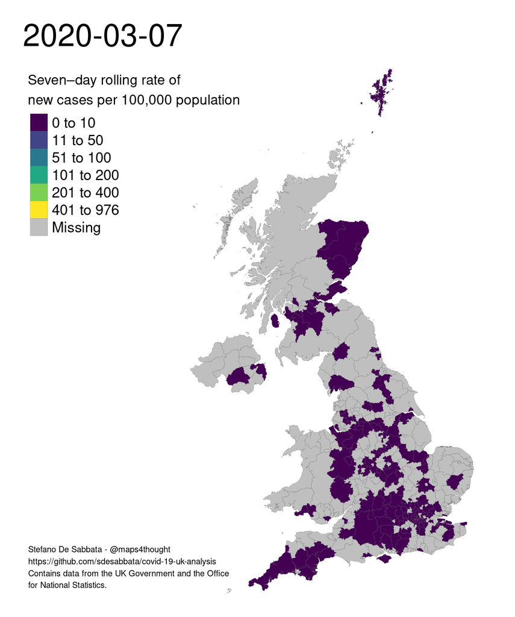

## tidyr::complete

Complete table by turning implicit missing values into explicit missing values

```r
city_info_long_noNAs %>%
  # Complete table with all week_ending and city combinations
  # making missing values for remaining columns explicit
  tidyr::complete(week_ending, city)
```

[output not shown]

## Summary

Tidy-up your data

- Wide and long data
- Re-shape data
- Handle missing values

**Next**: Read and write data

- file formats
- read
- write